# Statistics compared

E. Oziolor

April 25, 2018

# Comparisons

- I am comparing fst data calculated with Weir&Cockerham 1984 (with correction for sample size) to one calculated from pi
- Comparing pi calculated by comparing individual snps to one calculated by SFS in ANGSD

## Fst statistic

- Weir & Cockerham Fst estimation includes correction for sample size
  - that has given some odd substructuring paterns for BB and SJ, which Noah has noticed are not present when Fst is calculated from pi (0.5*(pi1+pi2)/dxy)
- Let’s take Noah’s data where pi and dxy are calculated on a per SNP basis and take global and local Fst plots from that.

###### scp -P 2022 farm:/home/nreid/noah_stats.RData ~/analysis/data/comparison/noah_stats.RData

```r
load("~/analysis/data/comparison/noah_stats.RData")
```

- starting with the PBS statistic comparisons
  - grabbing my data and plotting outlier windows

```r
library(XML)
library(magrittr)
library(stringr)
library(dplyr)
```

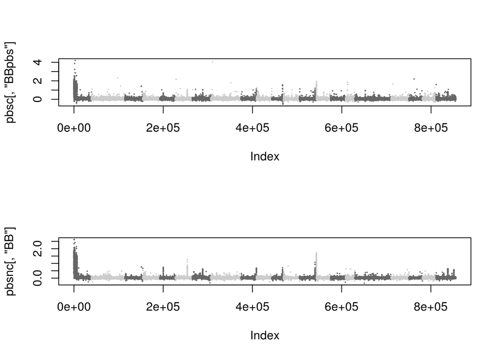

```r
library(gtools)
library(naturalsort)
library(stringr)
library(dplyr)
library(gtools)

#Reading in table and getting quantiles----
pbs<-read.table("~/analysis/data/fst/allpbs5kb",header=FALSE,stringsAsFactors = FALSE)
pbsname<-c("Scaf","start","end","BBpbs","VBpbs","PBpbs","SJpbs","BNPpbs","keep")
colnames(pbs)<-pbsname

pbsc<-pbs %>%
  filter(str_detect(Scaf,"chr"))


#Reorder Noah's data by chromosome
pbst<-cbind(lift[,1:3],pbstat[,4:10])
ord<-mixedorder(pbst$V1)
pbsn<-pbst[ord,]
#Plotting a regression against the PBS statistics calculated by Noah

pbsnc<-pbsn %>%
  filter(str_detect(V1,"chr"))


pbsc$Scaf<-factor(pbsc$Scaf,levels=c("chr1","chr2","chr3","chr4","chr5","chr6","chr7","chr8","chr9","chr10",
                                     "chr11","chr12","chr13","chr14","chr15","chr16","chr17","chr18","chr19",
                                     "chr20","chr21","chr22","chr23","chr24"))

pbsnc$V1<-factor(pbsnc$V1,levels=c("chr1","chr2","chr3","chr4","chr5","chr6","chr7","chr8","chr9","chr10",
                                     "chr11","chr12","chr13","chr14","chr15","chr16","chr17","chr18","chr19",
                                     "chr20","chr21","chr22","chr23","chr24"))

palette(c("grey40","grey80"))
par(mfrow=c(2,1))
plot(pbsc[,"BBpbs"],pch=20,cex=.2,col=as.factor(pbs[,1]))
plot(pbsnc[,"BB"],pch=20,cex=.2,col=as.factor(pbsn[,1]))
```

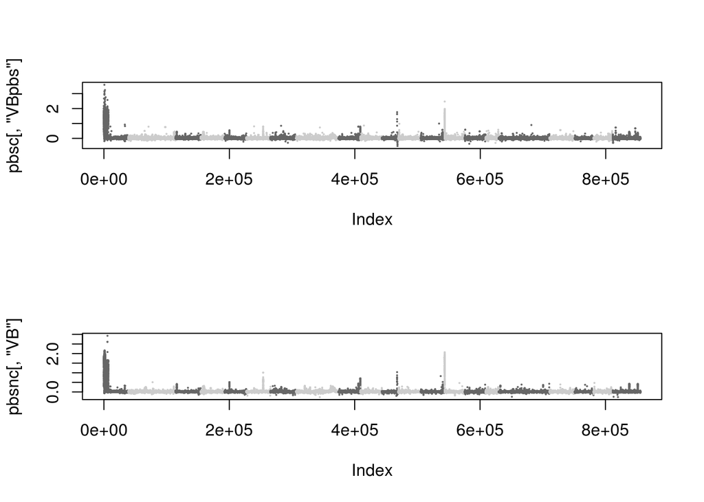

```r
par(mfrow=c(2,1))
plot(pbsc[,"VBpbs"],pch=20,cex=.2,col=as.factor(pbs[,1]))
plot(pbsnc[,"VB"],pch=20,cex=.2,col=as.factor(pbsn[,1]))
```

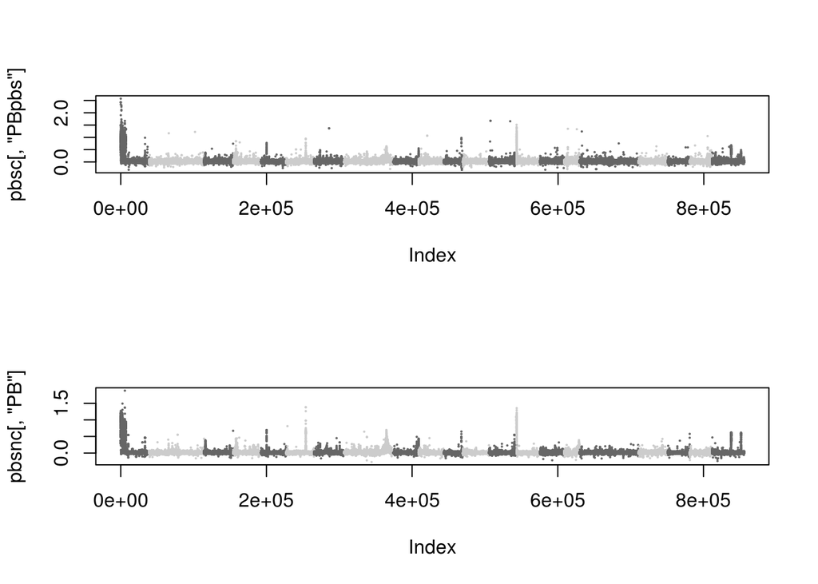

```r
par(mfrow=c(2,1))
plot(pbsc[,"PBpbs"],pch=20,cex=.2,col=as.factor(pbs[,1]))
plot(pbsnc[,"PB"],pch=20,cex=.2,col=as.factor(pbsn[,1]))
```

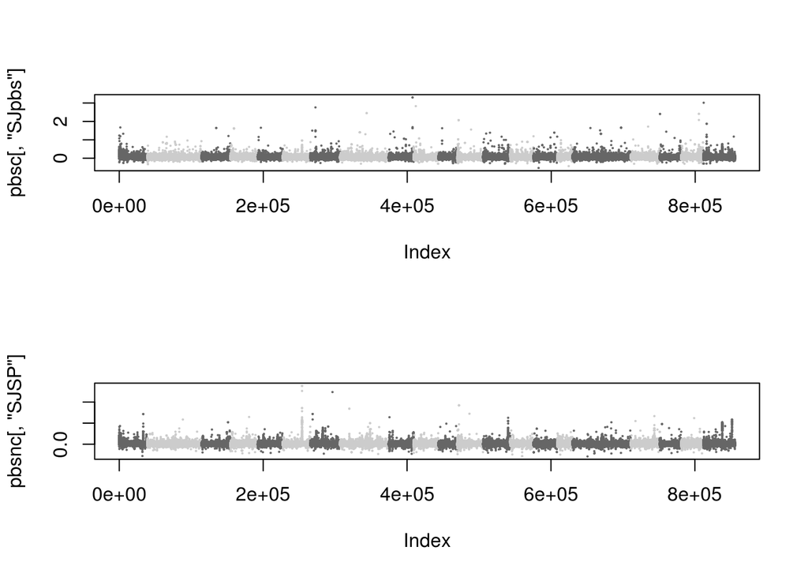

```r
par(mfrow=c(2,1))
plot(pbsc[,"SJpbs"],pch=20,cex=.2,col=as.factor(pbs[,1]))
plot(pbsnc[,"SJSP"],pch=20,cex=.2,col=as.factor(pbsn[,1]))
```

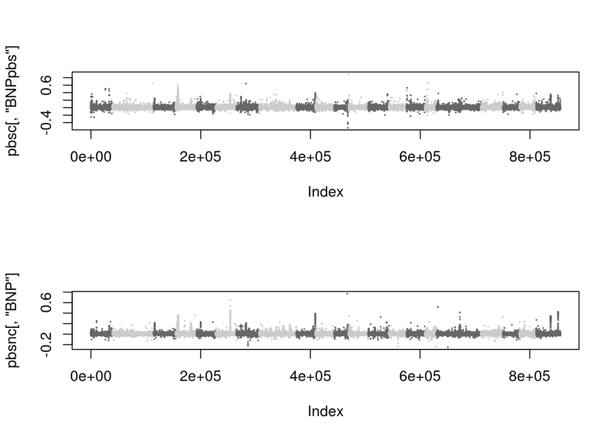

```r
par(mfrow=c(2,1))
plot(pbsc[,"BNPpbs"],pch=20,cex=.2,col=as.factor(pbs[,1]))
plot(pbsnc[,"BNP"],pch=20,cex=.2,col=as.factor(pbsn[,1]))
```

```r
library("RColorBrewer")
library("lattice")
library("gplots")
#Loaidng list of fst files into a list object ----
fs <- list.files("~/analysis/data/fst/raw/", "*5kb1kb.bed",full.names=TRUE) # listing all the files for Fst calculated with W&C fst statistic

fst <- list()

for (i in 1:21){
    fst[[i]] <- read.table(fs[i],stringsAsFactors=FALSE)
    fst[[i]][,4] <- as.numeric(fst[[i]][,4])
} #reading in those files
```

[output not shown]

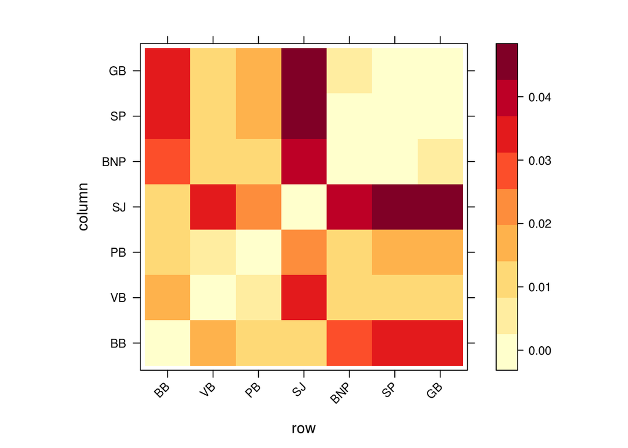

```r
nfs <- gsub(".*\\/","",fs) #renaming the columns by removing the "." in the names
nfs <- gsub(".fst.*","",nfs) #renaming by removing ".fst.*" from the name
names(fst)<-nfs

#selecting sites that ahave a minimum representation of 200 snps per region----
nsnps <-fst[[1]][,5]

for (i in 2:21){

  nsnps <- nsnps + fst[[i]][,5]
}

nsnps <- nsnps/21

subw <- nsnps > 20

#calculating FST for all

fstl<-c()
for(i in 1:21){
  fstl[i]<-mean(fst[[i]][subw,4],na.rm=TRUE)
} #global fst calculation for each pair

names(fstl)<-names(fst)

fsth<-matrix(nrow = 7,ncol=7) #creating matrix to hold fst data
colnames(fsth)<-c("BB","VB","PB","SJ","BNP","SP","GB")
rownames(fsth)<-c("BB","VB","PB","SJ","BNP","SP","GB")
fsth[1,]<-c(0,fstl["BB.VB"],fstl["BB.PB"],fstl["BB.SJ"],fstl["BB.BNP"],fstl["BB.SP"],fstl["BB.GB"]) #stupid, stupid way of doing this. I should automate, but oh well.
fsth[2,]<-c(fstl["BB.VB"],0,fstl["VB.PB"],fstl["VB.SJ"],fstl["VB.BNP"],fstl["VB.SP"],fstl["VB.GB"])
fsth[3,]<-c(fstl["BB.PB"],fstl["VB.PB"],0,fstl["PB.SJ"],fstl["PB.BNP"],fstl["PB.SP"],fstl["PB.GB"])
fsth[4,]<-c(fstl["BB.SJ"],fstl["VB.SJ"],fstl["PB.SJ"],0,fstl["SJ.BNP"],fstl["SJ.SP"],fstl["SJ.GB"])
fsth[5,]<-c(fstl["BB.BNP"],fstl["VB.BNP"],fstl["PB.BNP"],fstl["SJ.BNP"],0,fstl["BNP.SP"],fstl["BNP.GB"])
fsth[6,]<-c(fstl["BB.SP"],fstl["VB.SP"],fstl["PB.SP"],fstl["SJ.SP"],fstl["BNP.SP"],0,fstl["GB.SP"])
fsth[7,]<-c(fstl["BB.GB"],fstl["VB.GB"],fstl["PB.GB"],fstl["SJ.GB"],fstl["BNP.GB"],fstl["GB.SP"],0)


#heatfst<-heatmap.2(fsth,Rowv=NA,Colv=NA,scale="none",margins=c(5,10),col=brewer.pal(9,"YlOrRd"),
                   #density.info="none", trace="none")
levelplot(fsth,aspect="iso",col.regions=brewer.pal(9,"YlOrRd"),scale=list(x=list(rot=45)),cuts=8) #Better plot than above
```